# QK Box 10.6

Caballes et al. (2016) examined the effects of maternal nutrition (three treatments: starved or fed one of two coral genera: *Acropora* or *Porites*) on the larval biology of crown-of-thorns seastars. There were three female seastars nested within each treatment, 50 larvae reared from each female were placed into each of three glass culture jars and the lengths of ten larvae from each jar after four days were measured after 4 days. This fully balanced design has maternal nutrition as a fixed factor with three random levels of nesting: females within nutrition treatment, jars within females and individual larvae within jars.

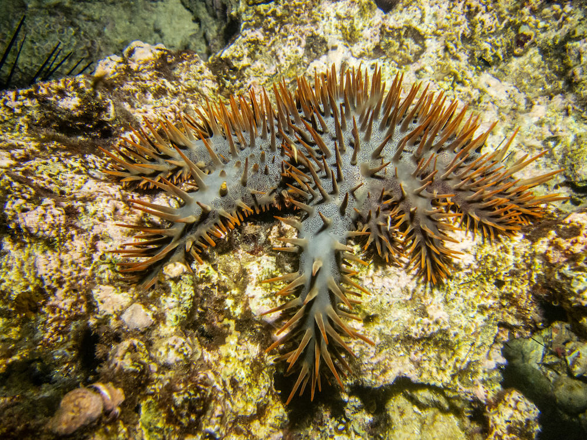

Crown of thorns seastar, Acanthaster planci. Mick Keough, [CC BY 4.0](https://creativecommons.org/licenses/by-sa/4.0)

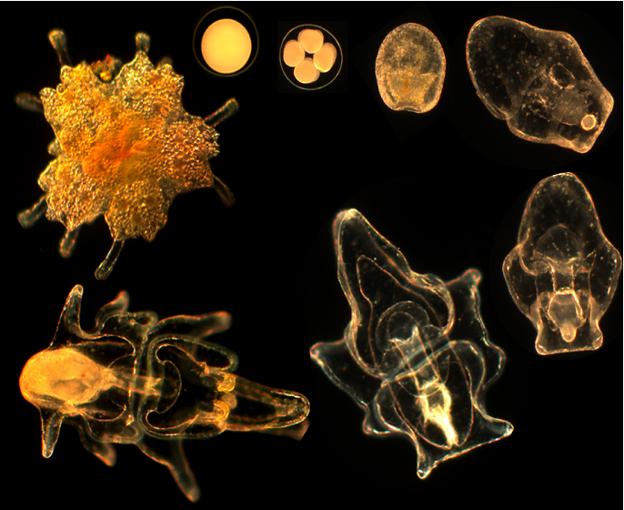

Larval cycle of crown-of-thorns. AIMS, [CC BY 4.0](https://creativecommons.org/licenses/by-sa/4.0)

The paper is here

Caballes, C. F., Pratchett, M. S., Kerr, A. M. & Rivera-Posada, J. A. (2016). The role of maternal nutrition on oocyte size and quality, with respect to early larval development in the coral-eating starfish, *Acanthaster planci*. *PLoS One*, 11, e0158007.

### Preliminaries

First, load the required packages (afex, car, lattice, lme4, lmerTest, nlme, VCA, Rmisc)

Import caballes data file (caballes_length.csv)

```r
caballes_length <- read.csv("../data/caballes_length.csv")
head(caballes_length,10)
```

|  | diet | female | jar | length |
| --- | --- | --- | --- | --- |
| 1 | starved | 1 | 1 | 0.638 |
| 2 | starved | 1 | 1 | 0.533 |
| 3 | starved | 1 | 1 | 0.476 |
| 4 | starved | 1 | 1 | 0.359 |
| 5 | starved | 1 | 1 | 0.354 |
| 6 | starved | 1 | 1 | 0.576 |
| 7 | starved | 1 | 1 | 0.742 |
| 8 | starved | 1 | 1 | 0.495 |
| 9 | starved | 1 | 1 | 0.803 |
| 10 | starved | 1 | 1 | 0.493 |

```r
set_sum_contrasts()
```

```
## setting contr.sum globally: options(contrasts=c('contr.sum', 'contr.poly'))
```

Make female and jar factors

```r
caballes_length$female <- factor(caballes_length$female)
caballes_length$jar <- factor(caballes_length$jar)
```

Reorder nutrition treatments so starved is first for default lm contrasts

```r
caballes_length$diet <- factor(caballes_length$diet, levels = c("starved","aa","pr"))
```

## Run model

**Note:** can’t get the aov commands to work for 3 level nested design

```r
caballes.aov <- aov(length~diet+Error(female/jar), caballes_length)
```

```
## Error in qr.qty(qr.e, resp): NA/NaN/Inf in foreign function call (arg 1)
```

### Fit as lm using OLS estimation

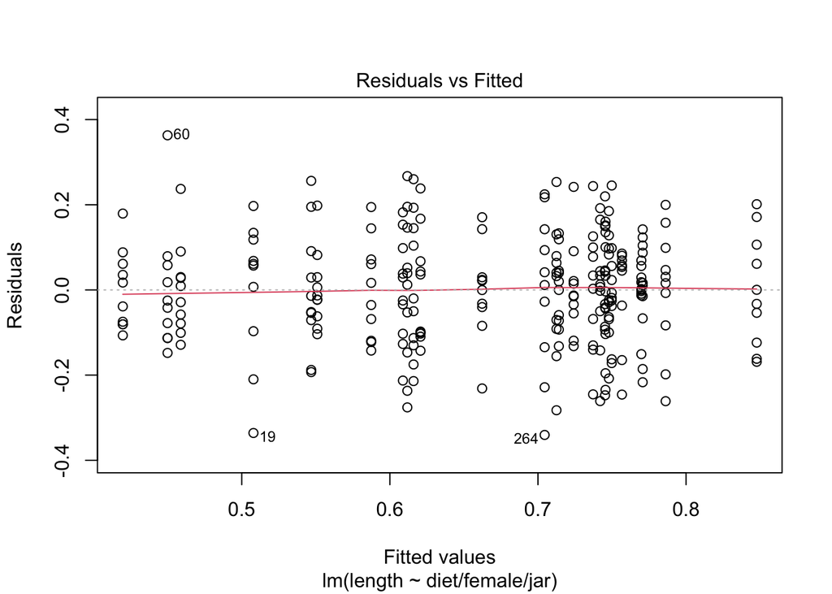

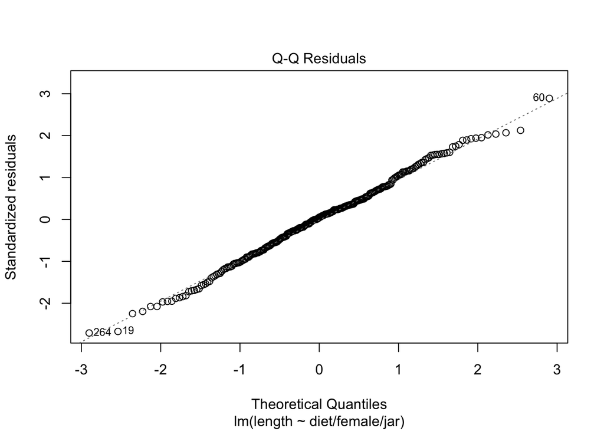

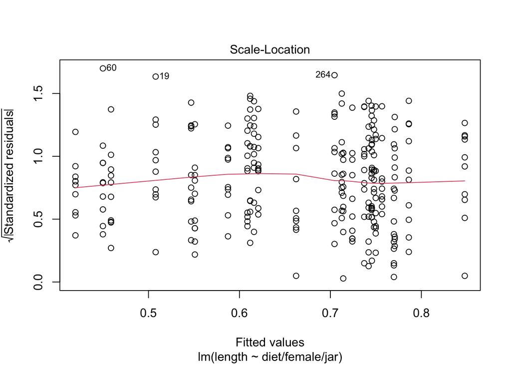

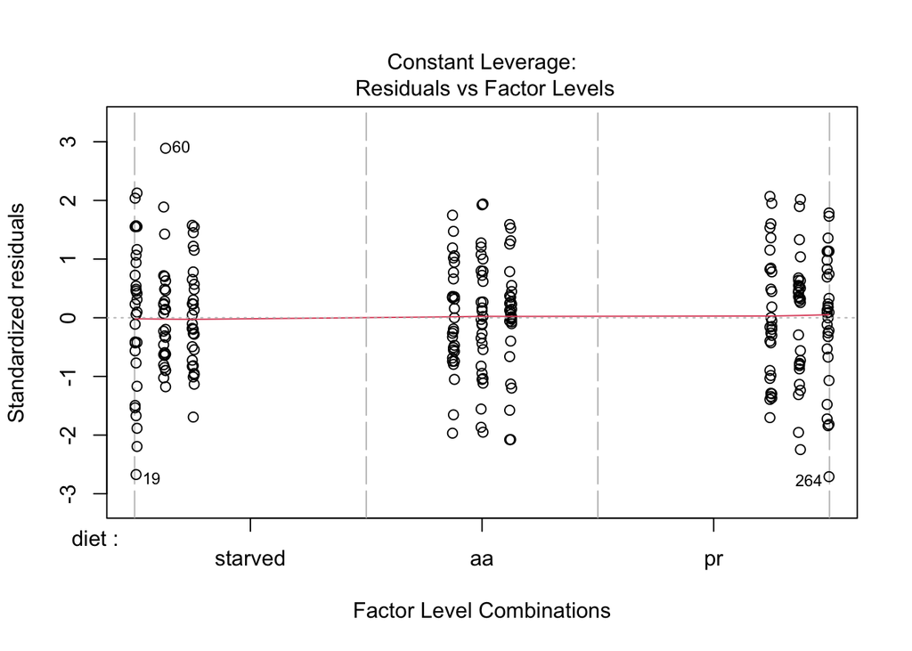

```r
caballes.lm <- lm(length ~ diet/female/jar, caballes_length)
plot(caballes.lm)
```

```r
summary(caballes.lm)
```

```
##
## Call:
## lm(formula = length ~ diet/female/jar, data = caballes_length)
##
## Residuals:
##      Min       1Q   Median       3Q      Max
## -0.34050 -0.08403  0.00650  0.08010  0.36310
##
## Coefficients: (702 not defined because of singularities)
##                           Estimate Std. Error t value Pr(>|t|)
## (Intercept)                0.68990    0.02419  28.521  < 2e-16 ***
## diet1                     -0.10250    0.03421  -2.996  0.00302 **
## diet2                      0.07990    0.03421   2.336  0.02032 *
## dietstarved:female1        0.02440    0.05925   0.412  0.68084
## dietaa:female1                  NA         NA      NA       NA
## dietpr:female1             0.01290    0.10262   0.126  0.90007
## dietstarved:female2       -0.13750    0.05925  -2.321  0.02113 *
## dietaa:female2                  NA         NA      NA       NA
## dietpr:female2                  NA         NA      NA       NA
## dietstarved:female3             NA         NA      NA       NA
## dietaa:female3                  NA         NA      NA       NA
## dietpr:female3                  NA         NA      NA       NA
## dietstarved:female4             NA         NA      NA       NA
## dietaa:female4            -0.05570    0.05925  -0.940  0.34811
## dietpr:female4                  NA         NA      NA       NA
## dietstarved:female5             NA         NA      NA       NA
## dietaa:female5            -0.03260    0.05925  -0.550  0.58268
## dietpr:female5                  NA         NA      NA       NA
## dietstarved:female6             NA         NA      NA       NA
## dietaa:female6                  NA         NA      NA       NA
## dietpr:female6                  NA         NA      NA       NA
## dietstarved:female7             NA         NA      NA       NA
## dietaa:female7                  NA         NA      NA       NA
## dietpr:female7             0.03730    0.05925   0.630  0.52959
## dietstarved:female8             NA         NA      NA       NA
## dietaa:female8                  NA         NA      NA       NA
## dietpr:female8                  NA         NA      NA       NA
## dietstarved:female1:jar1  -0.06490    0.05925  -1.095  0.27445
## dietaa:female1:jar1             NA         NA      NA       NA
## dietpr:female1:jar1             NA         NA      NA       NA
```

[output cut: 690 more lines]

```
## dietstarved:female7:jar26       NA         NA      NA       NA
## dietaa:female7:jar26            NA         NA      NA       NA
## dietpr:female7:jar26            NA         NA      NA       NA
## dietstarved:female8:jar26       NA         NA      NA       NA
## dietaa:female8:jar26            NA         NA      NA       NA
## dietpr:female8:jar26            NA         NA      NA       NA
## dietstarved:female9:jar26       NA         NA      NA       NA
## dietaa:female9:jar26            NA         NA      NA       NA
## dietpr:female9:jar26            NA         NA      NA       NA
## ---
## Signif. codes:  0 '***' 0.001 '**' 0.01 '*' 0.05 '.' 0.1 ' ' 1
##
## Residual standard error: 0.1325 on 243 degrees of freedom
## Multiple R-squared:  0.446,  Adjusted R-squared:  0.3867
## F-statistic: 7.523 on 26 and 243 DF,  p-value: < 2.2e-16
```

```r
anova(caballes.lm)
```

|  | Df | Sum Sq | Mean Sq | F value | Pr(>F) |
| --- | --- | --- | --- | --- | --- |
| diet | 2 | 2.5333650 | 1.26668248 | 72.162423 | 2.511924e-25 |
| diet:female | 6 | 0.3734596 | 0.06224326 | 3.545975 | 2.198542e-03 |
| diet:female:jar | 18 | 0.5265233 | 0.02925130 | 1.666435 | 4.598943e-02 |
| Residuals | 243 | 4.2654311 | 0.01755321 | NA | NA |

Get F and P values using correct denominators

```r
#Diet F
f <- 1.26668/0.06224
pf(f, df1 = 2, df2 = 6, lower.tail = FALSE)
```

```
## [1] 0.002120396
```

```r
#Females F
f <- 0.06224/0.02925
pf(f, df1 = 6, df2 = 18, lower.tail = FALSE)
```

```
## [1] 0.100229
```

```r
#Jars F
f <- 0.02925/0.01755
pf(f, df1 = 18, df2 = 243, lower.tail = FALSE)
```

```
## [1] 0.04594475
```

Variance components from VCA

```r
caballes.vca <- anovaMM(length ~ diet/(female)/(jar), caballes_length)
caballes.vca
```

```
##
##
## ANOVA-Type Estimation of Mixed Model:
## --------------------------------------
##
##  [Fixed Effects]
##
##         int      dietaa      dietpr dietstarved
##    0.526911    0.218889    0.188744    0.000000
##
##
##  [Variance Components]
##
##   Name            DF         SS       MS       VC       %Total    SD
## 1 total           200.914152                   0.019823 100       0.140793
## 2 diet:female     6          0.37346  0.062243 0.0011   5.547827  0.033162
## 3 diet:female:jar 18         0.526523 0.029251 0.00117  5.90134   0.034202
## 4 error           243        4.265431 0.017553 0.017553 88.550832 0.132489
##   CV[%]
## 1 21.242557
## 2 5.003435
## 3 5.160385
## 4 19.989554
##
## Mean: 0.662789 (N = 270)
##
## Experimental Design: balanced  |  Method: ANOVA
```

```r
VCAinference(caballes.vca, alpha = 0.05, VarVC = TRUE, ci.method = "satterthwaite")
```

```
##
##
##
## Inference from Mixed Model Fit
## ------------------------------
##
## > VCA Result:
## -------------
##
##  [Fixed Effects]
##
##         int      dietaa      dietpr dietstarved
##      0.5269      0.2189      0.1887      0.0000
##
##
##  [Variance Components]
##
##   Name            DF       SS     MS     VC     %Total  SD     CV[%]   Var(VC)
## 1 total           200.9142               0.0198 100     0.1408 21.2426 0
## 2 diet:female     6        0.3735 0.0622 0.0011 5.5478  0.0332 5.0034  0
## 3 diet:female:jar 18       0.5265 0.0293 0.0012 5.9013  0.0342 5.1604  0
## 4 error           243      4.2654 0.0176 0.0176 88.5508 0.1325 19.9896 0
##
## Mean: 0.6628 (N = 270)
##
## Experimental Design: balanced  |  Method: ANOVA
##
##
## > VC:
## -----
##                 Estimate       DF CI LCL CI UCL One-Sided LCL One-Sided UCL
## total             0.0198 200.9142 0.0165 0.0244        0.0169        0.0235
## diet:female       0.0011   1.5701 0.0003 0.1039        0.0003        0.0427
## diet:female:jar   0.0012   2.8040 0.0004 0.0188        0.0004        0.0112
## error             0.0176 243.0000 0.0148 0.0211        0.0152        0.0205
##
## > SD:
## -----
##                 Estimate       DF CI LCL CI UCL One-Sided LCL One-Sided UCL
## total             0.1408 200.9142 0.1283 0.1560        0.1302        0.1535
## diet:female       0.0332   1.5701 0.0164 0.3223        0.0184        0.2066
## diet:female:jar   0.0342   2.8040 0.0191 0.1371        0.0210        0.1058
## error             0.1325 243.0000 0.1217 0.1454        0.1233        0.1432
##
## > CV[%]:
## --------
##                 Estimate       DF  CI LCL  CI UCL One-Sided LCL One-Sided UCL
## total            21.2426 200.9142 19.3530 23.5442       19.6423       23.1536
## diet:female       5.0034   1.5701  2.4710 48.6259        2.7686       31.1672
## diet:female:jar   5.1604   2.8040  2.8837 20.6905        3.1612       15.9636
## error            19.9896 243.0000 18.3593 21.9400       18.6100       21.6107
##
##
## 95% Confidence Level
## Satterthwaite methodology used for computing CIs
```

### Fit mixed effects model using REML/ML

```r
caballes.lmer <- lmer(length ~ diet + (1|female/jar), caballes_length)
summary(caballes.lmer)
```

```
## Linear mixed model fit by REML. t-tests use Satterthwaite's method [
## lmerModLmerTest]
## Formula: length ~ diet + (1 | female/jar)
##    Data: caballes_length
##
## REML criterion at convergence: -289.2
##
## Scaled residuals:
##      Min       1Q   Median       3Q      Max
## -2.69014 -0.69659  0.01388  0.64143  2.59374
##
## Random effects:
##  Groups     Name        Variance Std.Dev.
##  jar:female (Intercept) 0.00117  0.03420
##  female     (Intercept) 0.00110  0.03316
##  Residual               0.01755  0.13249
## Number of obs: 270, groups:  jar:female, 27; female, 9
##
## Fixed effects:
##             Estimate Std. Error       df t value Pr(>|t|)
## (Intercept)  0.66279    0.01518  5.99986  43.652 9.68e-09 ***
## diet1       -0.13588    0.02147  5.99986  -6.328 0.000728 ***
## diet2        0.08301    0.02147  5.99986   3.866 0.008306 **
## ---
## Signif. codes:  0 '***' 0.001 '**' 0.01 '*' 0.05 '.' 0.1 ' ' 1
##
## Correlation of Fixed Effects:
##       (Intr) diet1
## diet1  0.000
## diet2  0.000 -0.500
```

Get F-ratio for diet test using lmerTest

```r
anova(caballes.lmer, ddf = "Kenward-Roger")
```

|  | Sum Sq | Mean Sq | NumDF | DenDF | F value | Pr(>F) |
| --- | --- | --- | --- | --- | --- | --- |
| diet | 0.7144186 | 0.3572093 | 2 | 6 | 20.35005 | 0.002120803 |

CI on variance components (remembering to square CIs from lmer which are in SD units)

```r
caballes.ci <- confint.merMod(caballes.lmer)
```

```
## Computing profile confidence intervals ...
```

```r
caballes.vc <- (caballes.ci)^2
print(caballes.vc)
```

```
##                   2.5 %      97.5 %
## .sig01      0.000000000 0.004051007
## .sig02      0.000000000 0.003177589
## .sigma      0.014769187 0.021083239
## (Intercept) 0.404053917 0.475997080
## diet1       0.030364676 0.009506432
## diet2       0.001992217 0.014735036
```